# L14

# Bayes’ Nets

## Review

- Efficient encoding of a probabilistic model of a domain
- Set of nodes, one per variable $X$
- Directed, acyclic graph
- Conditional distribution for each node
- Implicitly encode joint distributions
  - To see what probability a BN gives to a full assignment, multiply all of the relevant conditionals together: $\mathbb{P}(x_{1},x_{2},{\dots},x_{n})=\prod^{n}_{i=1}\mathbb{P}(x_{i}|\mathrm{parents}(X_{i}))$
- eg:

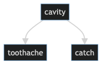

$\mathbb{P}(\text{+cavity},\text{+catch},\text{-toothache})=\mathbb{P}(\text{+cavity})\mathbb{P}(\text{-toothache}|\text{+cavity})\mathbb{P}(\text{+catch}|\text{+cavity})$ - eg2:

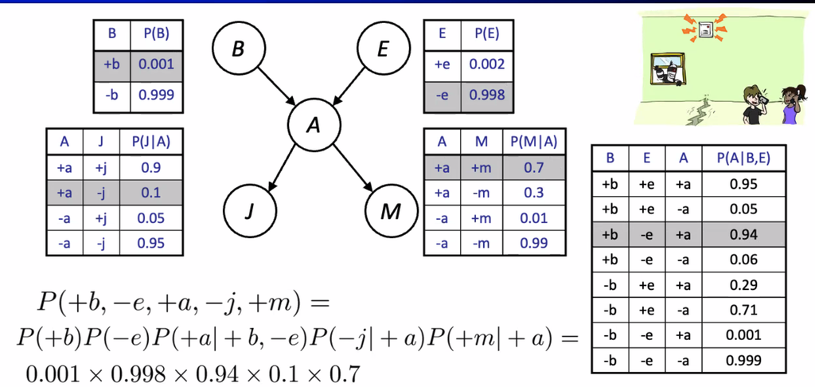

- Joint distribution over $N$ variables is $2^{N}$ rows - Bayes net of $N$ nodes with up to $k$ parents $\in{O(n*2^{k+1})}$

## Extracting Conditional Independence

- Can use the chain rule and bayes’ net reconstitution formula to pull apart factors and determine conditional independence
- Two variables $X$ and $Y$ are conditionally independent given $Z$ iff $\mathbb{P}(X,Y|Z)=\mathbb{P}(X|Z)\mathbb{P}(Y|Z)$

### D-Separation

- Study independence properties for triples
- Analyze complex cases in terms of member triples

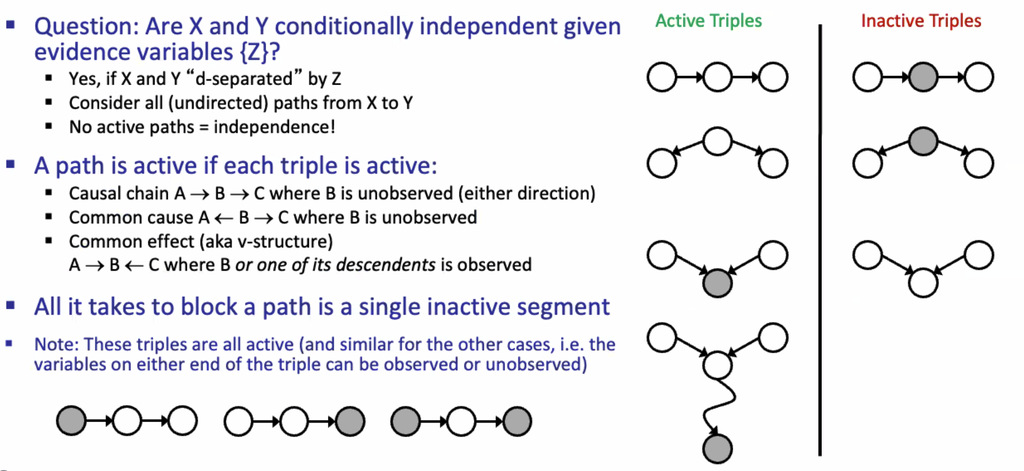

  - Shaded nodes ⟺ observed (taken as a given value)
- To determine conditional independence between $X_{i}$ and $X_{j}$, you have to check all possible (**UNDIRECTED**) paths $X_{i}\rightarrow{X_{j}}$ and see if there is a path s.t. every intermediary node is open
  - The intermediary nodes are triples along the path; open ⟺ active

## Topology Limits Distributions

- Adding arcs increases the set of distributions, but has several costs
- Full conditioning can encode any distribution